# Identify Customer Segments for Mail-order Sales company

### The top 6 most significant features with outliers included the following:

TITEL_KZ - Academic title flag  
AGER_TYP - Best-ager typology  
KK_KUNDENTYP - Consumer pattern over past 12 months  
KBA05_BAUMAX - Most common building type within the microcell  
GEBURTSJAHR - Year of birth  
ALTER_HH - Birthdate of head of household

#### I cannot seem to find any relation with these values. TITEL_KZ had the highest number of missing values with more than 90% however its removal would hardly affect the data and clustering algorithm as an individuals title would hardly be a determing feature in this dataset.

REGIOTYP - Neighborhood typology  
KKK - Purchasing power in region  
W_KEIT_KIND_HH - Likelihood of children in household  
KBA05_ANTG1 - Number of 1-2 family houses in the microcell  
MOBI_REGIO - Movement patterns  
KBA05_GBZ - Number of buildings in the microcell

#### These features might prove useful in data analysis since these features describe the econmic and social aspects of the demography. Purchasing power, movement patterns and number of buildings and neighbour describe an individuals/socities collective wealth while the strength of family members (childen, dependents) determines a families purchasing and economical needs.

#### Step 1.1.3: Assess Missing Data in Each Row

1. Assess missing data in each row
2. Divide the data into two subsets: one for data points that are above some threshold for missing values, and a second subset for points below that threshold.
3. Make observations regarding the results

```python
# How much data is missing in each row of the dataset?
missing_row = azdias.isnull().sum(axis=1).count()
missing_row
```

```
891221
```

```python
# Average value, can be used for seperating rows ahead
azdias.isnull().sum(axis = 1).mean()
```

```
5.649893797385833
```

```python
low_values = azdias[azdias.isnull().sum(axis = 1) < azdias.isnull().sum(axis = 1).mean()].copy()
high_values = azdias[azdias.isnull().sum(axis = 1) >= azdias.isnull().sum(axis = 1).mean()].copy()
```

```python
low_values.info()
```

```
<class 'pandas.core.frame.DataFrame'>
Int64Index: 719624 entries, 1 to 891220
Data columns (total 79 columns):
ALTERSKATEGORIE_GROB     718093 non-null float64
ANREDE_KZ                719624 non-null int64
CJT_GESAMTTYP            719624 non-null float64
FINANZ_MINIMALIST        719624 non-null int64
FINANZ_SPARER            719624 non-null int64
FINANZ_VORSORGER         719624 non-null int64
FINANZ_ANLEGER           719624 non-null int64
FINANZ_UNAUFFAELLIGER    719624 non-null int64
FINANZ_HAUSBAUER         719624 non-null int64
FINANZTYP                719624 non-null int64
GFK_URLAUBERTYP          719624 non-null float64
GREEN_AVANTGARDE         719624 non-null int64
HEALTH_TYP               704814 non-null float64
LP_LEBENSPHASE_FEIN      699921 non-null float64
LP_LEBENSPHASE_GROB      700048 non-null float64
LP_FAMILIE_FEIN          700049 non-null float64
LP_FAMILIE_GROB          700049 non-null float64
LP_STATUS_FEIN           719624 non-null float64
LP_STATUS_GROB           719624 non-null float64
NATIONALITAET_KZ         706345 non-null float64
PRAEGENDE_JUGENDJAHRE    712260 non-null float64
RETOURTYP_BK_S           719624 non-null float64
SEMIO_SOZ                719624 non-null int64
SEMIO_FAM                719624 non-null int64
SEMIO_REL                719624 non-null int64
SEMIO_MAT                719624 non-null int64
SEMIO_VERT               719624 non-null int64
SEMIO_LUST               719624 non-null int64
SEMIO_ERL                719624 non-null int64
SEMIO_KULT               719624 non-null int64
SEMIO_RAT                719624 non-null int64
SEMIO_KRIT               719624 non-null int64
SEMIO_DOM                719624 non-null int64
SEMIO_KAEM               719624 non-null int64
SEMIO_PFLICHT            719624 non-null int64
SEMIO_TRADV              719624 non-null int64
SHOPPER_TYP              704814 non-null float64
```

[output cut: 29 more lines]

```
ONLINE_AFFINITAET        719624 non-null float64
REGIOTYP                 680882 non-null float64
KBA13_ANZAHL_PKW         718982 non-null float64
PLZ8_ANTG1               719624 non-null float64
PLZ8_ANTG2               719624 non-null float64
PLZ8_ANTG3               719624 non-null float64
PLZ8_ANTG4               719624 non-null float64
PLZ8_BAUMAX              719624 non-null float64
PLZ8_HHZ                 719624 non-null float64
PLZ8_GBZ                 719624 non-null float64
ARBEIT                   716017 non-null float64
ORTSGR_KLS9              716093 non-null float64
RELAT_AB                 716017 non-null float64
dtypes: float64(51), int64(24), object(4)
memory usage: 439.2+ MB
```

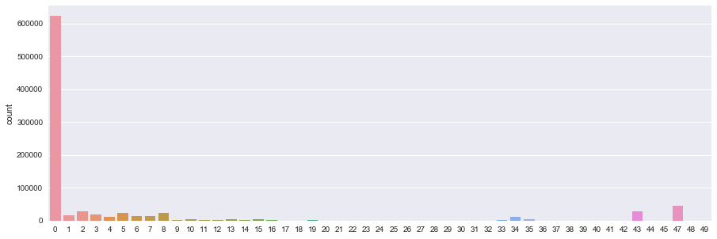

```python
# divide the data into two subsets based on the number of missingvalues in each row.
#sns.set(style="darkgrid")
sns.set(rc={'figure.figsize':(15,5)})
sns.countplot(azdias.isnull().sum(axis=1))
```

### Assess Quality of Data. Create Subsets

```python
low_values = azdias[azdias.isnull().sum(axis = 1) < azdias.isnull().sum(axis = 1).mean()].copy()
high_values = azdias[azdias.isnull().sum(axis = 1) >= azdias.isnull().sum(axis = 1).mean()].copy()
```

```python
low_values1 = missing_values_table(low_values)
low_values1[:10]
```

|  | Missing Values | % of Total Values |
| --- | --- | --- |
| W_KEIT_KIND_HH | 39782 | 5.5 |
| REGIOTYP | 38742 | 5.4 |
| KKK | 38742 | 5.4 |
| LP_LEBENSPHASE_FEIN | 19703 | 2.7 |
| LP_LEBENSPHASE_GROB | 19576 | 2.7 |
| LP_FAMILIE_FEIN | 19575 | 2.7 |
| LP_FAMILIE_GROB | 19575 | 2.7 |
| HEALTH_TYP | 14810 | 2.1 |
| VERS_TYP | 14810 | 2.1 |
| SHOPPER_TYP | 14810 | 2.1 |

```python
high_values1 = missing_values_table(high_values)
high_values1.tail(20)
```

|  | Missing Values | % of Total Values |
| --- | --- | --- |
| MIN_GEBAEUDEJAHR | 93148 | 54.3 |
| GEBAEUDETYP | 93148 | 54.3 |
| OST_WEST_KZ | 93148 | 54.3 |
| LP_LEBENSPHASE_FEIN | 77929 | 45.4 |
| LP_LEBENSPHASE_GROB | 74996 | 43.7 |
| KONSUMNAEHE | 73925 | 43.1 |
| SOHO_KZ | 73499 | 42.8 |
| WOHNDAUER_2008 | 73499 | 42.8 |
| ANZ_TITEL | 73499 | 42.8 |
| ANZ_PERSONEN | 73499 | 42.8 |
| LP_FAMILIE_GROB | 58217 | 33.9 |
| LP_FAMILIE_FEIN | 58217 | 33.9 |
| HH_EINKOMMEN_SCORE | 18348 | 10.7 |
| GFK_URLAUBERTYP | 4854 | 2.8 |
| CJT_GESAMTTYP | 4854 | 2.8 |
| LP_STATUS_FEIN | 4854 | 2.8 |
| LP_STATUS_GROB | 4854 | 2.8 |
| RETOURTYP_BK_S | 4854 | 2.8 |
| ONLINE_AFFINITAET | 4854 | 2.8 |
| ALTERSKATEGORIE_GROB | 1350 | 0.8 |

```python
low_values1[1:10]
```

|  | Missing Values | % of Total Values |
| --- | --- | --- |
| REGIOTYP | 38742 | 5.4 |
| KKK | 38742 | 5.4 |
| LP_LEBENSPHASE_FEIN | 19703 | 2.7 |
| LP_LEBENSPHASE_GROB | 19576 | 2.7 |
| LP_FAMILIE_FEIN | 19575 | 2.7 |
| LP_FAMILIE_GROB | 19575 | 2.7 |
| HEALTH_TYP | 14810 | 2.1 |
| VERS_TYP | 14810 | 2.1 |
| SHOPPER_TYP | 14810 | 2.1 |

### Compare the sliced datasets

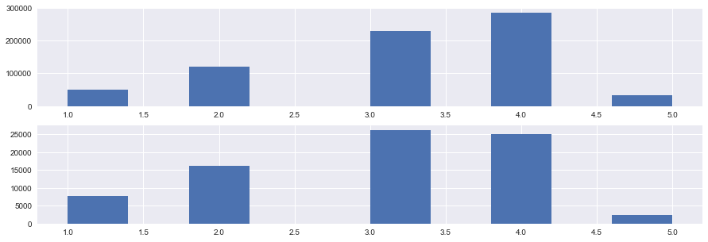

```python
fig1 = plt.figure()

ax1 = fig1.add_subplot(211)
ax1.hist(low_values['ARBEIT'].dropna())
ax2 = fig1.add_subplot(212)
ax2.hist(high_values['ARBEIT'].dropna())

plt.show()
```

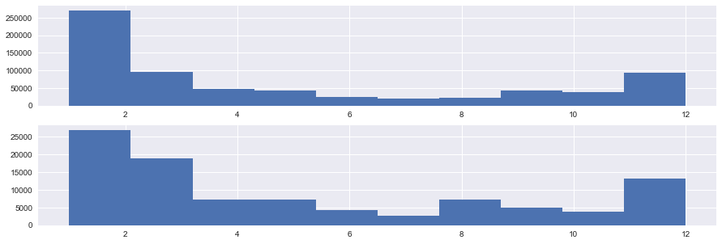

```python
fig1 = plt.figure()

ax1 = fig1.add_subplot(211)
ax1.hist(low_values['LP_LEBENSPHASE_GROB'].dropna())
ax2 = fig1.add_subplot(212)
ax2.hist(high_values['LP_LEBENSPHASE_GROB'].dropna())

plt.show()
```

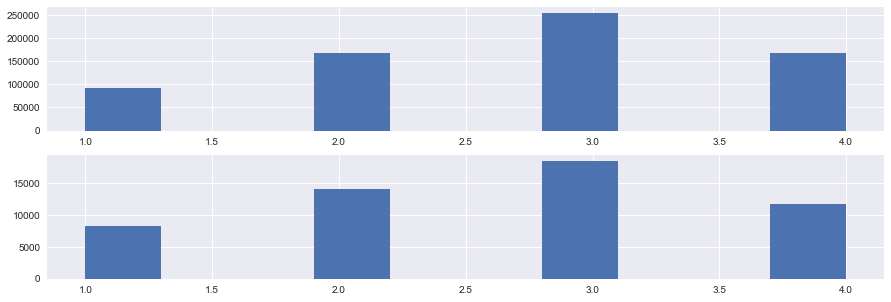

```python
fig1 = plt.figure()
ax1 = fig1.add_subplot(211)
ax1.hist(low_values['KKK'].dropna())
ax2 = fig1.add_subplot(212)
ax2.hist(high_values['KKK'].dropna())
plt.show()
```

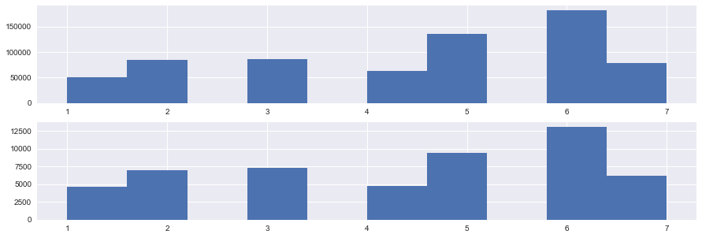

```python
fig1 = plt.figure()
ax1 = fig1.add_subplot(211)
ax1.hist(low_values['REGIOTYP'].dropna())
ax2 = fig1.add_subplot(212)
ax2.hist(high_values['REGIOTYP'].dropna())
plt.show()
```

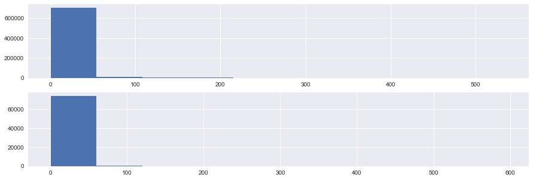

```python
fig1 = plt.figure()
ax1 = fig1.add_subplot(211)
ax1.hist(low_values['ANZ_HAUSHALTE_AKTIV'].dropna())
ax2 = fig1.add_subplot(212)
ax2.hist(high_values['ANZ_HAUSHALTE_AKTIV'].dropna())
plt.show()
```

#### Discussion 1.1.3: Assess Missing Data in Each Row

Criterion for seperation of the day was the mean of the sum of the number of null values

### Step 1.2: Select and Re-Encode Features

- For numeric and interval data, these features will be kept without changes.
- Most of the variables in the dataset are ordinal in nature. While ordinal values may technically be non-linear in spacing, make the simplifying assumption that the ordinal variables can be treated as being interval in nature (that is, kept without any changes).
- Special handling is done for the remaining two variable types: categorical, and 'mixed'.

```python
# Saving data to save computation
azdias.to_csv('data-edited.csv', sep=';')
```

```python
feat_info.head(4)
```

|  | attribute | information_level | type | missing_or_unknown |
| --- | --- | --- | --- | --- |
| 0 | AGER_TYP | person | categorical | [-1,0] |
| 1 | ALTERSKATEGORIE_GROB | person | ordinal | [-1,0,9] |
| 2 | ANREDE_KZ | person | categorical | [-1,0] |
| 3 | CJT_GESAMTTYP | person | categorical | [0] |

```python
# How many features are there of each data type?
feat_info['type'].value_counts()
```

```
ordinal        49
categorical    21
mixed           7
numeric         7
interval        1
Name: type, dtype: int64
```

#### Step 1.2.1: Re-Encode Categorical Features

Procssing Categorical data.

```python
# Assessing categorical variables: which are binary, which are multi-level, and which one needs to be re-encoded?
catagorical_val = feat_info[ feat_info['type'] == 'categorical']
```

```python
catagorical_val_cols = catagorical_val['attribute'].tolist()
```

```python
catagorical_val_cols
```

```
['AGER_TYP',
 'ANREDE_KZ',
 'CJT_GESAMTTYP',
 'FINANZTYP',
 'GFK_URLAUBERTYP',
 'GREEN_AVANTGARDE',
 'LP_FAMILIE_FEIN',
 'LP_FAMILIE_GROB',
 'LP_STATUS_FEIN',
 'LP_STATUS_GROB',
 'NATIONALITAET_KZ',
 'SHOPPER_TYP',
 'SOHO_KZ',
 'TITEL_KZ',
 'VERS_TYP',
 'ZABEOTYP',
 'KK_KUNDENTYP',
 'GEBAEUDETYP',
 'OST_WEST_KZ',
 'CAMEO_DEUG_2015',
 'CAMEO_DEU_2015']
```

```python
type(azdias)
```

```
pandas.core.frame.DataFrame
```

```python
##Find number of classes of catagorical data.
```

```python
categorical_data = pd.DataFrame(columns=['category', 'number'])
for i in catagorical_val_cols:
    if i in azdias:
        c = {'category': i, 'number': int(azdias[i].nunique()) }
        categorical_data = categorical_data.append(c, ignore_index=True)
        #print(i, azdias[i].nunique())
```

```python
categorical_data
```

|  | category | number |
| --- | --- | --- |
| 0 | ANREDE_KZ | 2 |
| 1 | CJT_GESAMTTYP | 6 |
| 2 | FINANZTYP | 6 |
| 3 | GFK_URLAUBERTYP | 12 |
| 4 | GREEN_AVANTGARDE | 2 |
| 5 | LP_FAMILIE_FEIN | 11 |
| 6 | LP_FAMILIE_GROB | 5 |
| 7 | LP_STATUS_FEIN | 10 |
| 8 | LP_STATUS_GROB | 5 |
| 9 | NATIONALITAET_KZ | 3 |
| 10 | SHOPPER_TYP | 4 |
| 11 | SOHO_KZ | 2 |
| 12 | VERS_TYP | 2 |
| 13 | ZABEOTYP | 6 |
| 14 | GEBAEUDETYP | 7 |
| 15 | OST_WEST_KZ | 2 |
| 16 | CAMEO_DEUG_2015 | 9 |
| 17 | CAMEO_DEU_2015 | 44 |

```python
categorical_data.columns
```

```
Index(['category', 'number'], dtype='object')
```

```python
categorical_data = categorical_data[categorical_data['number']  > 2]
```

```python
categorical_data
```

|  | category | number |
| --- | --- | --- |
| 1 | CJT_GESAMTTYP | 6 |
| 2 | FINANZTYP | 6 |
| 3 | GFK_URLAUBERTYP | 12 |
| 5 | LP_FAMILIE_FEIN | 11 |
| 6 | LP_FAMILIE_GROB | 5 |
| 7 | LP_STATUS_FEIN | 10 |
| 8 | LP_STATUS_GROB | 5 |
| 9 | NATIONALITAET_KZ | 3 |
| 10 | SHOPPER_TYP | 4 |
| 13 | ZABEOTYP | 6 |
| 14 | GEBAEUDETYP | 7 |
| 16 | CAMEO_DEUG_2015 | 9 |
| 17 | CAMEO_DEU_2015 | 44 |

```python
catagorical_val_cols_morethan2 = categorical_data['category']
```

```python
azdias.head()
```

|  | ALTERSKATEGORIE_GROB | ANREDE_KZ | CJT_GESAMTTYP | FINANZ_MINIMALIST | FINANZ_SPARER | FINANZ_VORSORGER | FINANZ_ANLEGER | FINANZ_UNAUFFAELLIGER | FINANZ_HAUSBAUER | FINANZTYP | ... | PLZ8_ANTG1 | PLZ8_ANTG2 | PLZ8_ANTG3 | PLZ8_ANTG4 | PLZ8_BAUMAX | PLZ8_HHZ | PLZ8_GBZ | ARBEIT | ORTSGR_KLS9 | RELAT_AB |
| --- | --- | --- | --- | --- | --- | --- | --- | --- | --- | --- | --- | --- | --- | --- | --- | --- | --- | --- | --- | --- | --- |
| 0 | 2.0 | 1 | 2.0 | 3 | 4 | 3 | 5 | 5 | 3 | 4 | ... | NaN | NaN | NaN | NaN | NaN | NaN | NaN | NaN | NaN | NaN |
| 1 | 1.0 | 2 | 5.0 | 1 | 5 | 2 | 5 | 4 | 5 | 1 | ... | 2.0 | 3.0 | 2.0 | 1.0 | 1.0 | 5.0 | 4.0 | 3.0 | 5.0 | 4.0 |
| 2 | 3.0 | 2 | 3.0 | 1 | 4 | 1 | 2 | 3 | 5 | 1 | ... | 3.0 | 3.0 | 1.0 | 0.0 | 1.0 | 4.0 | 4.0 | 3.0 | 5.0 | 2.0 |
| 3 | 4.0 | 2 | 2.0 | 4 | 2 | 5 | 2 | 1 | 2 | 6 | ... | 2.0 | 2.0 | 2.0 | 0.0 | 1.0 | 3.0 | 4.0 | 2.0 | 3.0 | 3.0 |
| 4 | 3.0 | 1 | 5.0 | 4 | 3 | 4 | 1 | 3 | 2 | 5 | ... | 2.0 | 4.0 | 2.0 | 1.0 | 2.0 | 3.0 | 3.0 | 4.0 | 6.0 | 5.0 |

5 rows × 79 columns

```python
catagorical_val_cols_morethan2
```

```
1        CJT_GESAMTTYP
2            FINANZTYP
3      GFK_URLAUBERTYP
5      LP_FAMILIE_FEIN
6      LP_FAMILIE_GROB
7       LP_STATUS_FEIN
8       LP_STATUS_GROB
9     NATIONALITAET_KZ
10         SHOPPER_TYP
13            ZABEOTYP
14         GEBAEUDETYP
16     CAMEO_DEUG_2015
17      CAMEO_DEU_2015
Name: category, dtype: object
```

#### I have decided to remove categorical data with more than 2 variables as I want to keep the data as simple as possible without adding more complexity to it. Only the required categorical features mentioned ahead on which one-hot encoding will be applied shall be used.

```python
for i in catagorical_val_cols_morethan2:
    if(i in azdias.columns):
        azdias.drop(columns=i, inplace=True)
```

```python
mixed_val = feat_info[ feat_info['type'] == 'mixed']
```

```python
# Mixed Values
```

[output not shown]

```python
azdias.head()
```

|  | ALTERSKATEGORIE_GROB | ANREDE_KZ | FINANZ_MINIMALIST | FINANZ_SPARER | FINANZ_VORSORGER | FINANZ_ANLEGER | FINANZ_UNAUFFAELLIGER | FINANZ_HAUSBAUER | GREEN_AVANTGARDE | HEALTH_TYP | ... | PLZ8_ANTG1 | PLZ8_ANTG2 | PLZ8_ANTG3 | PLZ8_ANTG4 | PLZ8_BAUMAX | PLZ8_HHZ | PLZ8_GBZ | ARBEIT | ORTSGR_KLS9 | RELAT_AB |
| --- | --- | --- | --- | --- | --- | --- | --- | --- | --- | --- | --- | --- | --- | --- | --- | --- | --- | --- | --- | --- | --- |
| 0 | 2.0 | 1 | 3 | 4 | 3 | 5 | 5 | 3 | 0 | NaN | ... | NaN | NaN | NaN | NaN | NaN | NaN | NaN | NaN | NaN | NaN |
| 1 | 1.0 | 2 | 1 | 5 | 2 | 5 | 4 | 5 | 0 | 3.0 | ... | 2.0 | 3.0 | 2.0 | 1.0 | 1.0 | 5.0 | 4.0 | 3.0 | 5.0 | 4.0 |
| 2 | 3.0 | 2 | 1 | 4 | 1 | 2 | 3 | 5 | 1 | 3.0 | ... | 3.0 | 3.0 | 1.0 | 0.0 | 1.0 | 4.0 | 4.0 | 3.0 | 5.0 | 2.0 |
| 3 | 4.0 | 2 | 4 | 2 | 5 | 2 | 1 | 2 | 0 | 2.0 | ... | 2.0 | 2.0 | 2.0 | 0.0 | 1.0 | 3.0 | 4.0 | 2.0 | 3.0 | 3.0 |
| 4 | 3.0 | 1 | 4 | 3 | 4 | 1 | 3 | 2 | 0 | 3.0 | ... | 2.0 | 4.0 | 2.0 | 1.0 | 2.0 | 3.0 | 3.0 | 4.0 | 6.0 | 5.0 |

5 rows × 66 columns

#### Discussion 1.2.1: Re-Encode Categorical Features

Have largely removed categorical variables with more than two features int them. The data already has much dimensions and adding more and investing energy at this time doesn't seem prudent. If the PCA doesn't yield a good accuracy/prediction later than we shall reconsider our decision and think about adding more classes either by engineering or by not dropping these coloumns.

```python
azdias.to_csv('data-edited-2.csv', sep=';')
```

#### Step 1.2.2: Engineer Mixed-Type Features

There are a handful of features that are marked as "mixed" in the feature summary that require special treatment in order to be included in the analysis. There are two in particular that deserve attention.

- "PRAEGENDE_JUGENDJAHRE" combines information on three dimensions: generation by decade, movement (mainstream vs. avantgarde), and nation (east vs. west).
- "CAMEO_INTL_2015" combines information on two axes: wealth and life stage.

```python
mixed_val_col = mixed_val['attribute'].tolist()
```

```python
azdias= pd.read_csv('data-edited-2.csv', sep=';')
```

```python
mixed_val = feat_info[ feat_info['type'] == 'mixed']
```

```python
# Categogrical Value feature seperation/one-hot-encoding
df.loc[df['PRAEGENDE_JUGENDJAHRE'].isin([1,3,5,8,10,12,14]),'MAINSTREAM']=1
df.loc[df['PRAEGENDE_JUGENDJAHRE'].isin([2,4,6,7,9,11,13,15]),'MAINSTREAM']=0

# WESTGERMANY. The OST_WEST_KZ feature could be used instead for seperation. 1 for True. 0 for False.
df.loc[df['OST_WEST_KZ']=='W','WESTGERMANY']=1
df.loc[df['OST_WEST_KZ']=='O','WESTGERMANY']=0

# Manuall seperation
df.loc[df['PRAEGENDE_JUGENDJAHRE'].isin([1,2]),'GENERATION']=1
df.loc[df['PRAEGENDE_JUGENDJAHRE'].isin([3,4]),'GENERATION']=2
df.loc[df['PRAEGENDE_JUGENDJAHRE'].isin([5,6,7]),'GENERATION']=3
df.loc[df['PRAEGENDE_JUGENDJAHRE'].isin([8,9]),'GENERATION']=4
df.loc[df['PRAEGENDE_JUGENDJAHRE'].isin([10,11,12,13]),'GENERATION']=5
df.loc[df['PRAEGENDE_JUGENDJAHRE'].isin([14,15]),'GENERATION']=6

# drop the initial coloum
df.drop('PRAEGENDE_JUGENDJAHRE', axis = 1, inplace=True)
df.drop('OST_WEST_KZ', axis = 1, inplace=True)

# Investigate "CAMEO_INTL_2015" and engineer new variables.
df.loc[df['CAMEO_INTL_2015'].isin(['11','12','13','14','15']),'HOUSEHOLD']=1
df.loc[df['CAMEO_INTL_2015'].isin(['21','22','23','24','25']),'HOUSEHOLD']=2
df.loc[df['CAMEO_INTL_2015'].isin(['31','32','33','34','35']),'HOUSEHOLD']=3
df.loc[df['CAMEO_INTL_2015'].isin(['41','42','43','44','45']),'HOUSEHOLD']=4
df.loc[df['CAMEO_INTL_2015'].isin(['51','52','53','54','55']),'HOUSEHOLD']=5
df.loc[df['CAMEO_INTL_2015'].isin(['11','21','31','41','51']),'LIFESTYLE']=1
df.loc[df['CAMEO_INTL_2015'].isin(['12','22','32','42','52']),'LIFESTYLE']=2
df.loc[df['CAMEO_INTL_2015'].isin(['13','23','33','43','53']),'LIFESTYLE']=3
df.loc[df['CAMEO_INTL_2015'].isin(['14','24','34','44','54']),'LIFESTYLE']=4
df.loc[df['CAMEO_INTL_2015'].isin(['15','25','35','45','55']),'LIFESTYLE']=5
df.drop('CAMEO_INTL_2015', axis = 1, inplace=True)
```

```python
# Drop remaining mixed values voloums
for i in mixed_val_col:
    if(i in azdias.columns):
        azdias.drop(columns=i, inplace=True)
```

#### Checkpoint

Saving and loading here because of heavy RAM use causes python to crash

```python
azdias.to_csv('data-edited-3.csv', sep=';')
```

```python
azdias= pd.read_csv('data-edited-3.csv', sep=';')
```

#### Discussion 1.2.2: Engineer Mixed-Type Features

- Multi - class categorical classes have been removed. I want to keep this data as simple as possible as creating/imputing more features creates a chance that there might be higher accuracy but would also require higher tuning.
- CAMEO_INTL_2015 & PRAEGENDE_JUGENDJAHRE have been classified with a speciific number assigned to each of them.

#### Step 1.2.3: Complete Feature Selection

In order to finish this step up, you need to make sure that your data frame now only has the columns that you want to keep. To summarize, the dataframe should consist of the following:

- All numeric, interval, and ordinal type columns from the original dataset.
- Binary categorical features (all numerically-encoded).
- Engineered features from other multi-level categorical features and mixed features.

Make sure that for any new columns that you have engineered, that you've excluded the original columns from the final dataset. Otherwise, their values will interfere with the analysis later on the project. For example, you should not keep "PRAEGENDE_JUGENDJAHRE", since its values won't be useful for the algorithm: only the values derived from it in the engineered features you created should be retained. As a reminder, your data should only be from **the subset with few or no missing values**.

### Step 1.3: Create a Cleaning Function

#### Note: This cleaning function neatly encapsulates all the data transformation done beforehand. This is a more easier way to understand the code. This function however does use two functions which are created in the beginning

```python
def clean_data(df):
    """
    Perform feature trimming, re-encoding, and engineering for demographics
    data

    INPUT: Demographics DataFrame
    OUTPUT: Trimmed and cleaned demographics DataFrame
    """
    # convert missing value codes into NaNs, ...
    print('Starting to clean data..')
    df = covert_Nan(df)
    missingVal = missing_values_table(df)
    outlier =missingVal['% of Total Values'].sort_values(ascending =False)
    # remove selected columns and rows, ...
    outliers = outlier.keys().tolist()
    # Remove the top 6 outliers which have a greater % of total missing values.
    for i in outliers[:6]:
        df.drop(columns=i, inplace=True)

    no_of_null_after = df.isnull().sum().sum()

    low_values = df[df.isnull().sum(axis = 1) < df.isnull().sum(axis = 1).mean()].copy()
    high_values = df[df.isnull().sum(axis = 1) >= df.isnull().sum(axis = 1).mean()].copy()

    low_values1 = missing_values_table(low_values)
    high_values1 = missing_values_table(high_values)

    # Note, function assumes feat_info dataframe has already been loaded since its not provided as an input
    catagorical_val = feat_info[ feat_info['type'] == 'categorical']
    # Feature names of categorical variables
    catagorical_val_cols = catagorical_val['attribute'].tolist()

    # Select and isolate categorical values to be viewed and possibly re-engineered
    categorical_data = pd.DataFrame(columns=['category', 'number'])

    for i in catagorical_val_cols:
        if i in df:
            c = {'category': i, 'number': int(df[i].nunique()) }
            categorical_data = categorical_data.append(c, ignore_index=True)

    # Select categorical values with more than 2 labels
    categorical_data = categorical_data[categorical_data['number']  > 2]
    catagorical_val_cols_morethan2 = categorical_data['category']

    # drop categorical values with more than two labels
    for i in catagorical_val_cols_morethan2:
        if(i in df.columns):
            df.drop(columns=i, inplace=True)

    # Mixed values manipluation starts

    # Isolate the values
    mixed_val = feat_info[ feat_info['type'] == 'mixed']
    mixed_val_col = mixed_val['attribute'].tolist()


    # Re engineer these values
    # create first new varibale: 'MAINSTREAM - YES OR NO'
    df.loc[df['PRAEGENDE_JUGENDJAHRE'].isin([1,3,5,8,10,12,14]),'MAINSTREAM']=1
    df.loc[df['PRAEGENDE_JUGENDJAHRE'].isin([2,4,6,7,9,11,13,15]),'MAINSTREAM']=0

    # WESTGERMANY.
    df.loc[df['OST_WEST_KZ']=='W','WESTGERMANY']=1
    df.loc[df['OST_WEST_KZ']=='O','WESTGERMANY']=0

    # I seperated each class and assigned it a value
    df.loc[df['PRAEGENDE_JUGENDJAHRE'].isin([1,2]),'GENERATION']=1
    df.loc[df['PRAEGENDE_JUGENDJAHRE'].isin([3,4]),'GENERATION']=2
    df.loc[df['PRAEGENDE_JUGENDJAHRE'].isin([5,6,7]),'GENERATION']=3
    df.loc[df['PRAEGENDE_JUGENDJAHRE'].isin([8,9]),'GENERATION']=4
    df.loc[df['PRAEGENDE_JUGENDJAHRE'].isin([10,11,12,13]),'GENERATION']=5
    df.loc[df['PRAEGENDE_JUGENDJAHRE'].isin([14,15]),'GENERATION']=6

    df.drop('PRAEGENDE_JUGENDJAHRE', axis = 1, inplace=True)
    df.drop('OST_WEST_KZ', axis = 1, inplace=True)

    # Investigate "CAMEO_INTL_2015" and engineer new standerdized variables.
    df.loc[df['CAMEO_INTL_2015'].isin(['11','12','13','14','15']),'HOUSEHOLD']=1
    df.loc[df['CAMEO_INTL_2015'].isin(['21','22','23','24','25']),'HOUSEHOLD']=2
    df.loc[df['CAMEO_INTL_2015'].isin(['31','32','33','34','35']),'HOUSEHOLD']=3
    df.loc[df['CAMEO_INTL_2015'].isin(['41','42','43','44','45']),'HOUSEHOLD']=4
    df.loc[df['CAMEO_INTL_2015'].isin(['51','52','53','54','55']),'HOUSEHOLD']=5
    df.loc[df['CAMEO_INTL_2015'].isin(['11','21','31','41','51']),'LIFESTYLE']=1
    df.loc[df['CAMEO_INTL_2015'].isin(['12','22','32','42','52']),'LIFESTYLE']=2
    df.loc[df['CAMEO_INTL_2015'].isin(['13','23','33','43','53']),'LIFESTYLE']=3
    df.loc[df['CAMEO_INTL_2015'].isin(['14','24','34','44','54']),'LIFESTYLE']=4
    df.loc[df['CAMEO_INTL_2015'].isin(['15','25','35','45','55']),'LIFESTYLE']=5
    df.drop('CAMEO_INTL_2015', axis = 1, inplace=True)
    #drop remaining mixed variables
    for i in mixed_val_col:
        if(i in df.columns):
            df.drop(columns=i, inplace=True)

    # Return the cleaned dataframe.
    print('Data cleaned!')
    return df
```

```python
# Technically one can start all over again from here since now the function is ready
azdias3 = pd.read_csv('Udacity_AZDIAS_Subset.csv', delimiter=';')
```

```python
azdias4 = clean_data(azdias3)
```

[output not shown]

### Checkpoint

Save/Load data

```python
azdias4.to_csv('azdias4.csv', sep=';')
```

```python
azdias4 = pd.read_csv('Udacity_AZDIAS_Subset.csv', delimiter=';')
```

```python
#azdias4.info()
```

## Step 2: Feature Transformation

### Step 2.1: Apply Feature Scaling

Before we apply dimensionality reduction techniques to the data, we need to perform feature scaling so that the principal component vectors are not influenced by the natural differences in scale for features.

```python
df = azdias4.copy()
```

Save categorical feature coloumn and data so that it can be used/referenced later

```python
# Extract all cols names with int type
cat_col_names = df.loc[:, df.dtypes == np.int64].columns
cat_col_names = cat_col_names.tolist()
```

```python
col_vals =df.columns.tolist()
```

```python
df_cols = list(set(col_vals) - set(cat_col_names))
```

```python
df_catogrical_data = df[df_cols]
```

```python
df_catogrical_data.head(1)
```

[output not shown]

Standerdize and remove missing values.

```python
imptr = Imputer(missing_values=float("NaN"), strategy="median", axis=1, copy = False)
scale = StandardScaler()
```

```python
df[df.columns] = scale.fit_transform(imptr.fit_transform(df))
```

```python
df.isnull().sum().sum()
```

```
0
```

```python
df.describe()
```

[output not shown]

8 rows × 64 columns

### Discussion 2.1: Apply Feature Scaling

I isolated that featured which were categorical and saved them in a variable. I then allowed those features to be standered, scaled and be turned into contionus variables so that the PCA can optimilly evaluate and predict. Once I have the output prediction variable, I would add back the saved categorical variables removed the scaled categorical values which may also have become contionus.

This is neccassry because I need to have categorical values to appropriatly anaylize the data.

### Step 2.2: Perform Dimensionality Reduction

Dimensionality reduction techniques are applied on scaled data

```python
def scree_plot(pca):
    '''
    Creates a scree plot associated with the principal components

    INPUT: pca - the result of instantian of PCA in scikit learn

    OUTPUT:
            None
    '''
    num_components=len(pca.explained_variance_ratio_)
    ind = np.arange(num_components)
    vals = pca.explained_variance_ratio_

    plt.figure(figsize=(10, 6))
    ax = plt.subplot(111)
    cumvals = np.cumsum(vals)
    ax.bar(ind, vals)
    ax.plot(ind, cumvals)
    for i in range(num_components):
        ax.annotate(r"%s%%" % ((str(vals[i]*100)[:4])), (ind[i]+0.2, vals[i]), va="bottom", ha="center", fontsize=12)

    ax.xaxis.set_tick_params(width=0)
    ax.yaxis.set_tick_params(width=2, length=12)

    ax.set_xlabel("Principal Component")
    ax.set_ylabel("Variance Explained (%)")
    plt.title('Explained Variance Per Principal Component')
```

```python
def pca_results(full_dataset, pca):
	'''
	Create a DataFrame of the PCA results
	Includes dimension feature weights and explained variance
	Visualizes the PCA results
	'''

	# Dimension indexing
	dimensions = dimensions = ['Dimension {}'.format(i) for i in range(1,len(pca.components_)+1)]

	# PCA components
	components = pd.DataFrame(np.round(pca.components_, 4), columns = full_dataset.keys())
	components.index = dimensions

	# PCA explained variance
	ratios = pca.explained_variance_ratio_.reshape(len(pca.components_), 1)
	variance_ratios = pd.DataFrame(np.round(ratios, 4), columns = ['Explained Variance'])
	variance_ratios.index = dimensions

	# Create a bar plot visualization
	fig, ax = plt.subplots(figsize = (16,8))

	# Plot the feature weights as a function of the components
	components.plot(ax = ax, kind = 'bar');
	ax.set_ylabel("Feature Weights")
	ax.set_xticklabels(dimensions, rotation=0)


	# Display the explained variance ratios
	for i, ev in enumerate(pca.explained_variance_ratio_):
		ax.text(i-0.40, ax.get_ylim()[1] + 0.05, "Explained Variance\n          %.4f"%(ev))

	# Return a concatenated DataFrame
	return pd.concat([variance_ratios, components], axis = 1)
```

#### I am running various PCA on the different of features to have a look at varience. Udacities function for the plot was used.

|  | Explained Variance | ALTERSKATEGORIE_GROB | ANREDE_KZ | FINANZ_MINIMALIST | FINANZ_SPARER | FINANZ_VORSORGER | FINANZ_ANLEGER | FINANZ_UNAUFFAELLIGER | FINANZ_HAUSBAUER | GREEN_AVANTGARDE | ... | PLZ8_HHZ | PLZ8_GBZ | ARBEIT | ORTSGR_KLS9 | RELAT_AB | MAINSTREAM | WESTGERMANY | GENERATION | HOUSEHOLD | LIFESTYLE |
| --- | --- | --- | --- | --- | --- | --- | --- | --- | --- | --- | --- | --- | --- | --- | --- | --- | --- | --- | --- | --- | --- |
| count | 63.000000 | 63.000000 | 63.000000 | 63.000000 | 63.000000 | 63.000000 | 63.000000 | 63.000000 | 63.000000 | 63.000000 | ... | 63.000000 | 63.000000 | 63.000000 | 63.000000 | 63.000000 | 63.000000 | 63.000000 | 63.000000 | 63.000000 | 63.000000 |
| mean | 0.015875 | 0.007719 | 0.000154 | 0.005629 | -0.018090 | -0.005152 | -0.007905 | 0.010516 | -0.019481 | -0.003144 | ... | 0.002219 | -0.023027 | 0.026925 | -0.019892 | 0.001532 | 0.009549 | 0.000863 | -0.016065 | 0.001106 | -0.010156 |
| std | 0.028927 | 0.126762 | 0.127002 | 0.126874 | 0.125681 | 0.126887 | 0.126756 | 0.126562 | 0.125468 | 0.126962 | ... | 0.116123 | 0.115461 | 0.124071 | 0.125410 | 0.126989 | 0.126633 | 0.126998 | 0.125959 | 0.126996 | 0.126588 |
| min | 0.000000 | -0.233300 | -0.441700 | -0.516600 | -0.717800 | -0.325400 | -0.365700 | -0.285400 | -0.476100 | -0.375000 | ... | -0.523100 | -0.448600 | -0.139500 | -0.743300 | -0.438600 | -0.348900 | -0.507000 | -0.691800 | -0.324700 | -0.615700 |
| 25% | 0.001300 | -0.017900 | -0.034100 | -0.038100 | -0.037400 | -0.071750 | -0.070800 | -0.048400 | -0.062000 | -0.037400 | ... | -0.012100 | -0.027650 | -0.021400 | -0.033600 | -0.026650 | -0.026800 | -0.046950 | -0.033500 | -0.019200 | -0.021850 |
| 50% | 0.004700 | -0.000100 | -0.000100 | -0.000300 | -0.001300 | -0.001300 | -0.003400 | 0.001400 | -0.000900 | 0.002400 | ... | 0.001600 | -0.001400 | 0.000100 | -0.004900 | -0.001200 | -0.003700 | -0.002800 | -0.006600 | -0.001300 | -0.003200 |
| 75% | 0.015750 | 0.011750 | 0.017800 | 0.060750 | 0.032250 | 0.042000 | 0.031600 | 0.038900 | 0.038450 | 0.042550 | ... | 0.016850 | 0.007200 | 0.028150 | 0.010350 | 0.018350 | 0.013100 | 0.048200 | 0.013600 | 0.016550 | 0.018800 |
| max | 0.147600 | 0.566100 | 0.459400 | 0.313700 | 0.206400 | 0.369600 | 0.433900 | 0.445300 | 0.313400 | 0.299100 | ... | 0.476100 | 0.280000 | 0.584100 | 0.386500 | 0.520300 | 0.693900 | 0.404300 | 0.384600 | 0.625400 | 0.545200 |

8 rows × 65 columns

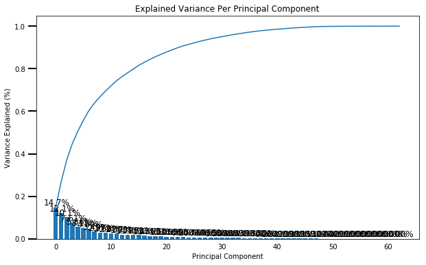

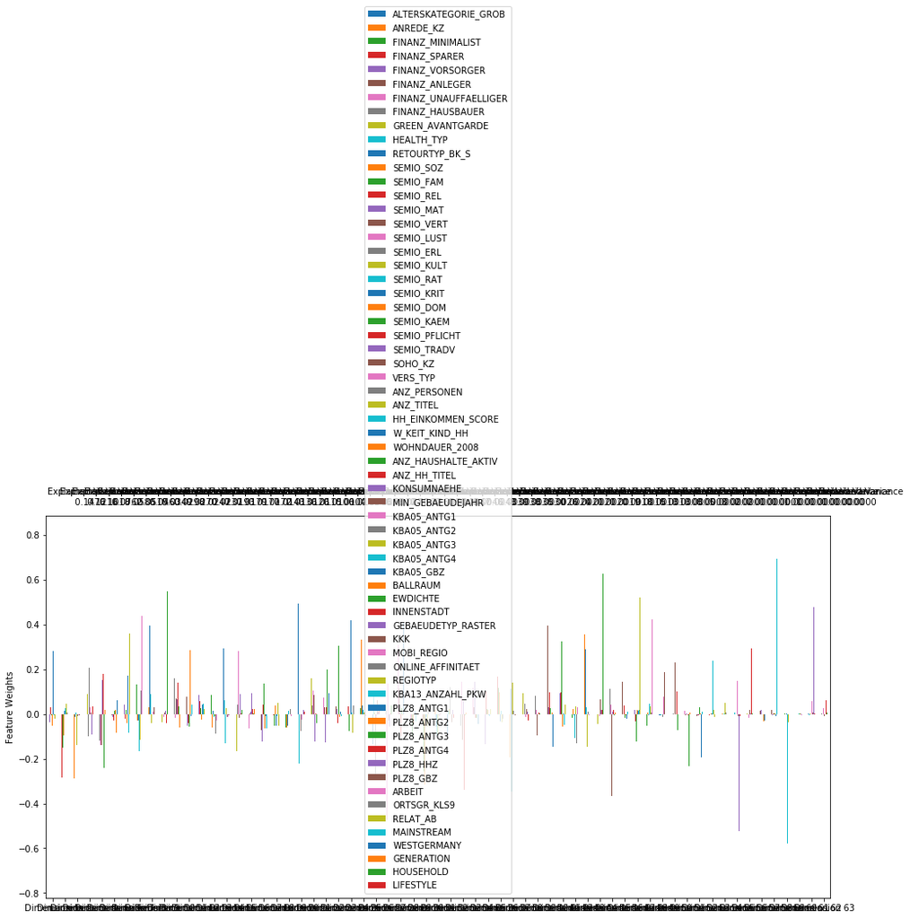

```python
pca = PCA(63)
df_pca = pca.fit_transform(df)
scree_plot(pca)
pca_results(df,pca).describe()
```

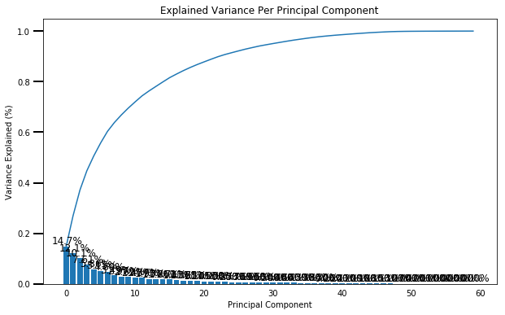

```python
pca = PCA(60)
df_pca = pca.fit_transform(df)
scree_plot(pca)
```

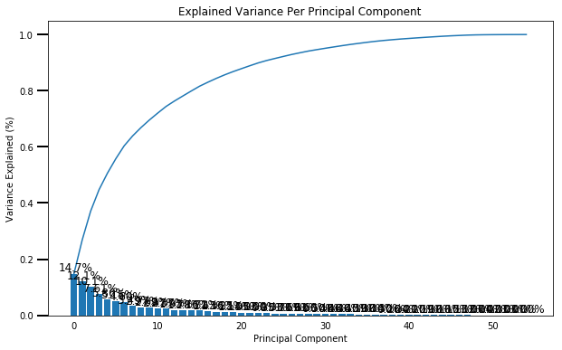

```python
pca = PCA(55)
df_pca = pca.fit_transform(df)
scree_plot(pca)
```

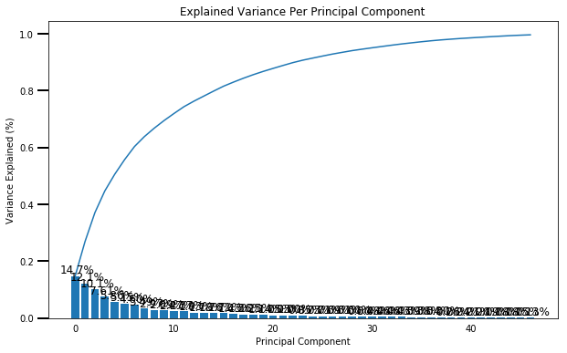

```python
pca = PCA(47)
df_pca = pca.fit_transform(df)
scree_plot(pca)
```

[figure not shown]

```python
# Re-apply PCA to the data while selecting for number of components to retain.
pca = PCA(60)
df_pca = pca.fit_transform(df)
scree_plot(pca)
```

[figure not shown]

```python
components = pca_results(df,pca)
```

```python
components.head(12)
```

|  | Explained Variance | ALTERSKATEGORIE_GROB | ANREDE_KZ | FINANZ_MINIMALIST | FINANZ_SPARER | FINANZ_VORSORGER | FINANZ_ANLEGER | FINANZ_UNAUFFAELLIGER | FINANZ_HAUSBAUER | GREEN_AVANTGARDE | ... | PLZ8_HHZ | PLZ8_GBZ | ARBEIT | ORTSGR_KLS9 | RELAT_AB | MAINSTREAM | WESTGERMANY | GENERATION | HOUSEHOLD | LIFESTYLE |
| --- | --- | --- | --- | --- | --- | --- | --- | --- | --- | --- | --- | --- | --- | --- | --- | --- | --- | --- | --- | --- | --- |
| Dimension 1 | 0.1476 | -0.0120 | -0.0066 | 0.0297 | 0.0291 | -0.0365 | 0.0324 | 0.0776 | -0.0957 | 0.0018 | ... | 0.2617 | 0.2661 | -0.0182 | -0.0367 | -0.0198 | 0.0214 | 0.0258 | 0.0266 | 0.0408 | 0.0657 |
| Dimension 2 | 0.1216 | 0.0962 | -0.0403 | 0.1849 | -0.2826 | 0.2283 | -0.2715 | -0.2754 | -0.0232 | 0.0859 | ... | 0.0365 | 0.0396 | -0.0207 | 0.0053 | -0.0255 | -0.0497 | -0.2102 | -0.0551 | -0.0155 | 0.0155 |
| Dimension 3 | 0.1018 | -0.0602 | -0.2888 | -0.0066 | 0.0955 | -0.1160 | -0.0159 | 0.0332 | -0.0540 | 0.0245 | ... | -0.0040 | -0.0076 | 0.0017 | 0.0280 | -0.0012 | -0.0364 | -0.1307 | 0.0038 | 0.0021 | -0.0224 |
| Dimension 4 | 0.0762 | 0.0035 | -0.1807 | 0.2915 | -0.1128 | 0.1093 | -0.0398 | 0.0113 | -0.2201 | 0.0901 | ... | -0.0937 | -0.0686 | -0.0789 | -0.1793 | -0.0813 | -0.1458 | 0.2402 | -0.1860 | -0.0746 | 0.0317 |
| Dimension 5 | 0.0586 | -0.0505 | 0.1506 | -0.0149 | 0.0729 | -0.1184 | 0.1212 | 0.0573 | -0.1194 | 0.0304 | ... | -0.2106 | -0.1890 | -0.1395 | -0.1806 | -0.1518 | -0.0271 | -0.1246 | 0.0161 | -0.1183 | -0.0481 |
| Dimension 6 | 0.0515 | 0.1537 | -0.1069 | 0.0467 | -0.0197 | 0.0834 | -0.0061 | 0.0154 | 0.0230 | -0.0459 | ... | -0.0809 | -0.0766 | -0.0440 | -0.0630 | -0.0416 | 0.4157 | 0.0611 | 0.3846 | -0.0124 | -0.0018 |
| Dimension 7 | 0.0460 | -0.0044 | -0.0461 | -0.0168 | -0.0331 | 0.0405 | -0.0864 | 0.0019 | 0.0410 | -0.0071 | ... | -0.1727 | -0.1916 | 0.3576 | 0.3865 | 0.3593 | -0.0538 | 0.0425 | -0.0667 | -0.0075 | -0.0628 |
| Dimension 8 | 0.0349 | 0.0141 | 0.0442 | 0.1314 | 0.0152 | -0.0442 | 0.0842 | 0.0283 | -0.1887 | 0.1591 | ... | 0.0583 | 0.0845 | 0.4382 | 0.2786 | 0.4252 | 0.0510 | -0.0296 | 0.0729 | -0.0433 | 0.0598 |
| Dimension 9 | 0.0298 | 0.0059 | 0.0303 | 0.0808 | -0.0074 | -0.0074 | -0.0977 | 0.0446 | -0.1310 | 0.2991 | ... | 0.0357 | 0.0289 | -0.1127 | 0.0314 | -0.0986 | 0.0059 | 0.0185 | 0.0306 | -0.3247 | -0.2817 |
| Dimension 10 | 0.0270 | -0.0193 | 0.0070 | -0.0098 | -0.0079 | -0.0018 | 0.0013 | -0.0256 | 0.0197 | -0.0369 | ... | -0.0481 | -0.0506 | -0.0227 | -0.0225 | -0.0289 | 0.0053 | -0.0267 | 0.0034 | 0.5481 | 0.5452 |
| Dimension 11 | 0.0247 | -0.0030 | -0.0289 | -0.1086 | 0.0107 | 0.0324 | 0.0933 | -0.0507 | 0.1572 | -0.3276 | ... | 0.0291 | 0.0279 | 0.0677 | -0.0284 | 0.0610 | -0.0306 | 0.0181 | -0.0598 | -0.2496 | -0.3148 |
| Dimension 12 | 0.0237 | 0.0133 | -0.0287 | -0.1199 | 0.0589 | -0.0226 | 0.0763 | 0.0148 | 0.1335 | -0.2035 | ... | -0.0168 | -0.0127 | 0.0407 | -0.0504 | 0.0423 | 0.0409 | -0.0221 | 0.0350 | -0.0802 | -0.1449 |

12 rows × 65 columns

### Discussion 2.2: Perform Dimensionality Reduction

Considering the fact that I already have used a lower number of dimensions as I didn't work on additional categorical features int the raw data and that the curve showed above just coverges and tapers towards infinity as it reaches 1.0 at a relatvelynarrow margin shows that I should not drastically alter the number of features.

Having fiddled with the data, Granted than reducing feature won't significantly impact varience regardless I believe I should keep to the number of features to 60 I have and not reduce this furthur to ensure that I maintain good results. The time and resouce complexity can be disregarded for such small changes in this case.

### Step 2.3: Interpret Principal Components

Now that we have our transformed principal components, it's a nice idea to check out the weight of each variable on the first few components to see if they can be interpreted in some fashion.

[figure not shown]

```python
# components = pca_results(df,pca)
```

```python
type(components)
```

```
pandas.core.frame.DataFrame
```

```python
# Map weights for the first principal component to corresponding feature names and then print the linked values, sorted by weight.

def get_weights(df, number):
    #input components dataframe
    # Outuput Series
    cmp_num = 'Dimension ' +str(number);
    #print(cmp_num)
    cmp = df.T[cmp_num].sort_values(ascending=False)
    return cmp


pc_1 = get_weights(components, 1)
pc_2 = get_weights(components, 2)
pc_3 = get_weights(components, 3)
```

```python
type(pc_1)
```

```
pandas.core.series.Series
```

```python
pc_1
```

[output not shown]